# NS-Forest v3.9.1

## Readme

NS-Forest v3.9.1 works directly with an [anndata](https://anndata.readthedocs.io/en/latest/) object. Call `NSForest` function below.

`NSForest(adata, cluster_header, cluster_list=None, medians_header=None, n_trees=1000, n_jobs=-1, beta=0.5, n_top_genes=15, n_binary_genes=10, n_genes_eval=6,output_folder="NSForest_outputs/")`

Parameters:

- `adata`: anndata object.
- `cluster_header`: Specify the header name of clusters in `adata.obs`.
- `cluster_list = None`: Give a selected list of clusters to perform on. By default, all clusters.
- `medians_header = None`: Specify the header name of pre-calucated cluster medians in `adata.varm`.
- `n_trees = 1000`: Number of trees in the random forest (RF). See `n_estimators` in [`sklearn.ensemble.RandomForestClassifier`](https://scikit-learn.org/stable/modules/generated/sklearn.ensemble.RandomForestClassifier.html).
- `n_jobs = -1`: Number of jobs to run in parallel. See [`sklearn.ensemble.RandomForestClassifier`](https://scikit-learn.org/stable/modules/generated/sklearn.ensemble.RandomForestClassifier.html).
- `beta = 0.5`: Beta value in F-beta score. See [`sklearn.metrics.fbeta_score`](https://scikit-learn.org/stable/modules/generated/sklearn.metrics.fbeta_score.html).
- `n_top_genes = 15`: Number of top RF genes to evaluate for binaryness.
- `n_binary_genes = 10`: Number of top binary genes to output.
- `n_genes_eval = 6`: Number top genes from double-ranking (RF and binaryness) to evaluate for combinatorial classification.
- `output_folder = "NSForest_outputs/"`: Specify the output folder.

# Tutorial

```python
import pandas as pd
import numpy as np
import scanpy as sc

from NSForest_v3dot9_1 import *
```

## Data

```python
data_folder = "demo data/"
adata = sc.read_h5ad(data_folder + "adata_layer1.h5ad") #<---
```

```python
adata #quick look of the data
```

```
AnnData object with n_obs × n_vars = 871 × 16497
    obs: 'cluster'
```

```python
## assign the header name for the cluster labels
cluster_header = "cluster" #<---
```

```python
## check the clusters
set(adata.obs[cluster_header])
```

```
{'e1_e299_SLC17A7_L5b_Cdh13',
 'g1_g48_GLI3_Astro_Gja1',
 'g2_g27_APBB1IP_Micro_Ctss',
 'g3_g18_GPNMB_OPC_Pdgfra',
 'g4_g9_MOG_Oligo_Opalin',
 'i10_i16_TSPAN12_Vip_Mybpc1',
 'i11_i6_EGF_Vip_Mybpc1',
 'i1_i90_COL5A2_Ndnf_Car4',
 'i2_i77_LHX6_Sst_Cbln4',
 'i3_i56_BAGE2_Ndnf_Cxcl14',
 'i4_i54_MC4R_Ndnf_Cxcl14',
 'i5_i47_TRPC3_Ndnf_Car4',
 'i6_i44_GPR149_Vip_Mybpc1',
 'i7_i31_CLMP_Ndnf_Cxcl14',
 'i8_i27_SNCG_Vip_Mybpc1',
 'i9_i22_TAC3_Vip_Mybpc1'}
```

## Run NS-Forest

### Run over a selected list of clusters

```python
## run over a selected list of clusters
NSForest_results_selected = NSForest(adata, cluster_header=cluster_header, n_trees=100, n_genes_eval=6,
                                     cluster_list=['e1_e299_SLC17A7_L5b_Cdh13','g1_g48_GLI3_Astro_Gja1']) #<---
```

```
Preparing data...
--- 0.005445003509521484 seconds ---
Calculating medians...
--- 0.40106868743896484 seconds ---
Number of clusters to evaluate: 2
1 out of 2:
	e1_e299_SLC17A7_L5b_Cdh13
	['TESPA1', 'SV2B']
	0.9828178694158075
2 out of 2:
	g1_g48_GLI3_Astro_Gja1
	['EZR', 'FGFR3']
	0.9308510638297872
--- 1.2347710132598877 seconds ---
```

```python
## look at the results
NSForest_results_selected
```

|  | clusterName | f_score | PPV | TN | FP | FN | TP | marker_count | NSForest_markers | binary_genes |
| --- | --- | --- | --- | --- | --- | --- | --- | --- | --- | --- |
| 0 | e1_e299_SLC17A7_L5b_Cdh13 | 0.982818 | 0.989619 | 569 | 3 | 13 | 286 | 2 | [TESPA1, SV2B] | [KIAA1211L, HOPX, TESPA1, CUX2, CYP1B1_AS1, SV... |
| 1 | g1_g48_GLI3_Astro_Gja1 | 0.930851 | 1.000000 | 823 | 0 | 13 | 35 | 2 | [EZR, FGFR3] | [EMX2OS, FAM189A2, EZR, PAPLN, FGFR3, SLCO1C1,... |

### Run over all clusters (by default)

```python
## by default, run over all clusters
NSForest_results = NSForest(adata, cluster_header=cluster_header, n_trees=100, n_genes_eval=6) #<---
```

```
Preparing data...
--- 0.004155874252319336 seconds ---
Calculating medians...
--- 0.35634779930114746 seconds ---
Number of clusters to evaluate: 16
1 out of 16:
	e1_e299_SLC17A7_L5b_Cdh13
	['TESPA1', 'SV2B']
	0.9828178694158075
2 out of 16:
	g1_g48_GLI3_Astro_Gja1
	['EZR', 'FGFR3']
	0.9308510638297872
3 out of 16:
	g2_g27_APBB1IP_Micro_Ctss
	['PLCG2']
	0.9565217391304346
4 out of 16:
	g3_g18_GPNMB_OPC_Pdgfra
	['GPNMB', 'VCAN']
	0.9090909090909091
5 out of 16:
	g4_g9_MOG_Oligo_Opalin
	['ST18']
	1.0
6 out of 16:
	i10_i16_TSPAN12_Vip_Mybpc1
	['CHRNB3', 'HCRTR2', 'COL12A1']
	0.7142857142857143
7 out of 16:
	i11_i6_EGF_Vip_Mybpc1
	['EGF', 'COPZ1']
	0.5555555555555555
8 out of 16:
	i1_i90_COL5A2_Ndnf_Car4
	['COL5A2', 'SV2C']
	0.9049079754601227
9 out of 16:
	i2_i77_LHX6_Sst_Cbln4
	['SYTL5', 'SOX6']
```

[output cut: 15 more lines]

```
	['FLT1', 'GPR149']
	0.7916666666666666
14 out of 16:
	i7_i31_CLMP_Ndnf_Cxcl14
	['PAX6', 'TGFBR2']
	0.9009009009009009
15 out of 16:
	i8_i27_SNCG_Vip_Mybpc1
	['SNCG', 'LINC01109']
	0.7831325301204819
16 out of 16:
	i9_i22_TAC3_Vip_Mybpc1
	['MCTP2', 'IQGAP2']
	0.7926829268292683
--- 10.439274072647095 seconds ---
```

```python
## look at the results
NSForest_results
```

|  | clusterName | f_score | PPV | TN | FP | FN | TP | marker_count | NSForest_markers | binary_genes |
| --- | --- | --- | --- | --- | --- | --- | --- | --- | --- | --- |
| 0 | e1_e299_SLC17A7_L5b_Cdh13 | 0.982818 | 0.989619 | 569 | 3 | 13 | 286 | 2 | [TESPA1, SV2B] | [KIAA1211L, HOPX, TESPA1, CUX2, CYP1B1_AS1, SV... |
| 1 | g1_g48_GLI3_Astro_Gja1 | 0.930851 | 1.000000 | 823 | 0 | 13 | 35 | 2 | [EZR, FGFR3] | [EMX2OS, FAM189A2, EZR, PAPLN, FGFR3, SLCO1C1,... |
| 2 | g2_g27_APBB1IP_Micro_Ctss | 0.956522 | 1.000000 | 844 | 0 | 5 | 22 | 1 | [PLCG2] | [PLCG2, MS4A14, ITGAX, RBM47, LINC01141, CD53,... |
| 3 | g3_g18_GPNMB_OPC_Pdgfra | 0.909091 | 1.000000 | 853 | 0 | 6 | 12 | 2 | [GPNMB, VCAN] | [STK32A, COL9A2, GPNMB, CSPG4, LHFPL3_AS1, VCA... |
| 4 | g4_g9_MOG_Oligo_Opalin | 1.000000 | 1.000000 | 862 | 0 | 0 | 9 | 1 | [ST18] | [MOG, MYRF, ST18, OPALIN, CD22, ERMN, DOCK5, B... |
| 5 | i10_i16_TSPAN12_Vip_Mybpc1 | 0.714286 | 0.800000 | 853 | 2 | 8 | 8 | 3 | [CHRNB3, HCRTR2, COL12A1] | [ZNF223, LINC01539, CHRNB3, HCRTR2, CRH, COL12... |
| 6 | i11_i6_EGF_Vip_Mybpc1 | 0.555556 | 0.666667 | 864 | 1 | 4 | 2 | 2 | [EGF, COPZ1] | [EGF, SNHG25, KCNIP2_AS1, DPF2, COPZ1, TMED5, ... |
| 7 | i1_i90_COL5A2_Ndnf_Car4 | 0.904908 | 1.000000 | 781 | 0 | 31 | 59 | 2 | [COL5A2, SV2C] | [COL5A2, TRPC3, CBLN4, NPNT, FREM1, SV2C, LINC... |
| 8 | i2_i77_LHX6_Sst_Cbln4 | 0.950156 | 1.000000 | 794 | 0 | 16 | 61 | 2 | [SYTL5, SOX6] | [LHX6, SYTL5, RASGRF2, PLCH1, SOX6, TENM1, KIA... |
| 9 | i3_i56_BAGE2_Ndnf_Cxcl14 | 0.843023 | 1.000000 | 815 | 0 | 27 | 29 | 2 | [BAGE2, THSD7B] | [BAGE2, GREM2, GRB14, ADAMTSL1, SEMA3C, THSD7B... |
| 10 | i4_i54_MC4R_Ndnf_Cxcl14 | 0.842697 | 0.967742 | 816 | 1 | 24 | 30 | 2 | [ADAM33, BCAS1] | [MC4R, LINC01435, ADAM33, FAM19A4, BCAS1, NTN4... |
| 11 | i5_i47_TRPC3_Ndnf_Car4 | 0.906433 | 1.000000 | 824 | 0 | 16 | 31 | 2 | [NTNG1, EYA4] | [PRSS12, SSTR2, NTNG1, TARID, EYA4, CA2, NRG1_... |
| 12 | i6_i44_GPR149_Vip_Mybpc1 | 0.791667 | 1.000000 | 827 | 0 | 25 | 19 | 2 | [FLT1, GPR149] | [FLT1, CXCL12, SLC22A3, GPR149, SHISA8, IGFBP5... |
| 13 | i7_i31_CLMP_Ndnf_Cxcl14 | 0.900901 | 1.000000 | 840 | 0 | 11 | 20 | 2 | [PAX6, TGFBR2] | [KIAA1644, CLMP, PAX6, CPLX3, TGFBR2, WIF1, AB... |
| 14 | i8_i27_SNCG_Vip_Mybpc1 | 0.783133 | 0.928571 | 843 | 1 | 14 | 13 | 2 | [SNCG, LINC01109] | [SNCG, MMRN2, EDNRA, LBH, KCNK2, LINC01109, AR... |
| 15 | i9_i22_TAC3_Vip_Mybpc1 | 0.792683 | 0.866667 | 847 | 2 | 9 | 13 | 2 | [MCTP2, IQGAP2] | [BSPRY, MCTP2, VWC2L_IT1, IQGAP2, CCNG2, VIP, ... |

## Plots

### NS-Forest marker genes

```python
## store cluster-marker information in a dictionary
markers = dict(zip(NSForest_results['clusterName'], NSForest_results['NSForest_markers']))
```

```
WARNING: dendrogram data not found (using key=dendrogram_cluster). Running `sc.tl.dendrogram` with default parameters. For fine tuning it is recommended to run `sc.tl.dendrogram` independently.
WARNING: You’re trying to run this on 16497 dimensions of `.X`, if you really want this, set `use_rep='X'`.
         Falling back to preprocessing with `sc.pp.pca` and default params.
```

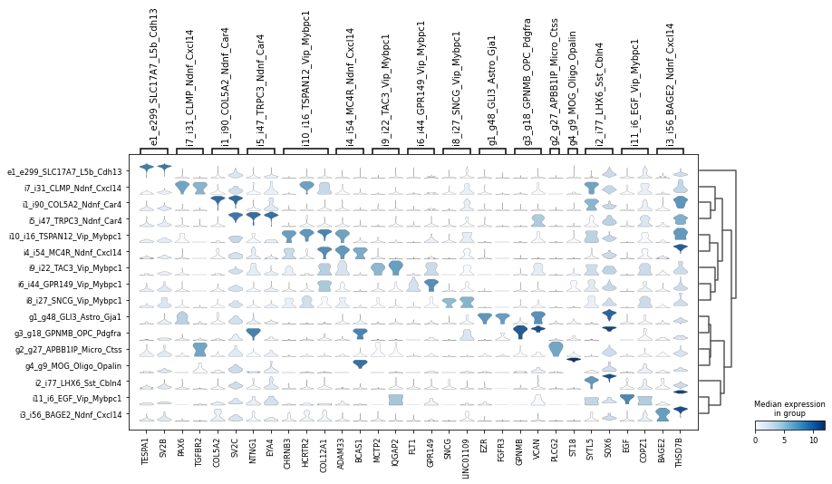

```python
## use scanpy plot function to plot the marker genes
sc.pl.stacked_violin(adata, markers, groupby=cluster_header, dendrogram=True)
```

### Binary genes

```python
# binary_genes = dict(zip(NSForest_results['clusterName'], NSForest_results['binary_genes']))
```

```python
# sc.pl.stacked_violin(adata, binary_genes, groupby=cluster_header, dendrogram=True, swap_axes=True)
```

## Save report to html

Click the "save" buttom before converting to html.

```python
!jupyter nbconvert --to html NS-Forest_tutorial.ipynb #<---
```

```
[NbConvertApp] Converting notebook NS-Forest_tutorial.ipynb to html
[NbConvertApp] Writing 827761 bytes to NS-Forest_tutorial.html
```

```python
!python --version
```

```
Python 3.8.8
```

```python
sc.__version__
```

```
'1.8.2'
```